# Continuous time Markov processes

Jarad Niemi

2023-03-09

R code

```r
library("tidyverse"); theme_set(theme_bw())
set.seed(20230307)
```

# Exponential Distribution

The exponential distribution is commonly used as a *waiting time* distribution, i.e. the time until something happens.

## Probability density function

A random variable $X$ has an exponential distribution if its density function is
$$f(x) = \lambda e^{-\lambda x} \quad \mbox{for }x>0$$
for rate $\lambda>0$.

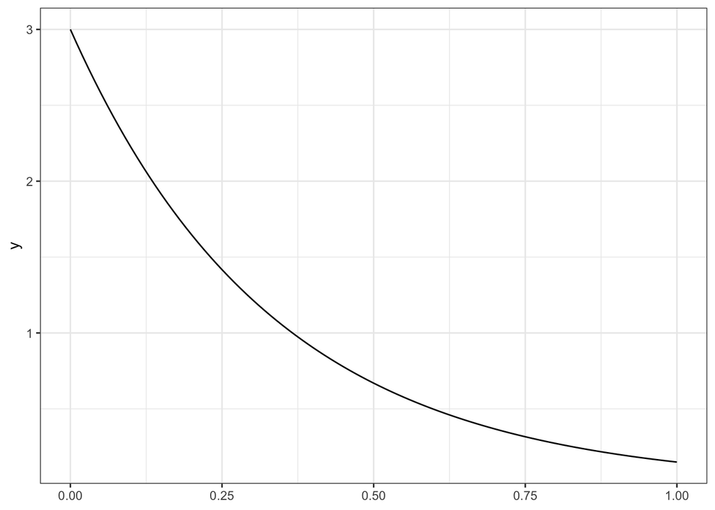

```r
r <- 3 # rate

ggplot(data.frame(x = 0:(4/r))) +
  stat_function(fun = dexp, args = list(rate = r))
```

The probability density function is strictly decreasing for any rate.

Note: Some parameterizations of the exponential use the mean rather than the rate as the parameter.

## Cumulative distribution function

The cumulative distribution function is
$$F(x) = P(X \le x) = 1-e^{-\lambda x} \quad \mbox{for }x > 0.$$

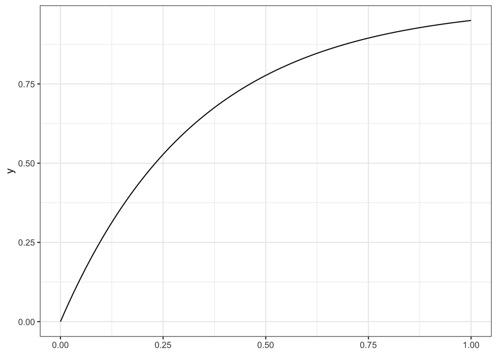

```r
ggplot(data.frame(x = 0:(4/r))) +
  stat_function(fun = pexp, args = list(rate = r))
```

## Memoryless property

The probability of being greater than some value has a simple form for the exponential distribution.
$$P(X > x) = 1-P(X\le x) = e^{-\lambda x}.$$

The exponential distribution has a property called the memoryless property that states
$$P(X > x+c | X > c) = P(X > x) = e^{-\lambda x}$$

For example,

```r
c <- 1

# Check probability
1-pexp(c, rate = r) # if this probability is too small, the simulation will take a while
```

```
## [1] 0.04978707
```

```r
# Simulate exponential random variables that are greater than c
x <- rexp(1e4, rate = r)
for (i in seq_along(x)) {
  while (x[i] < c)
    x[i] <- rexp(1, rate = r)
}
```

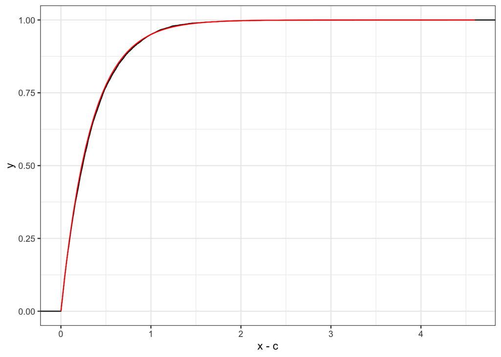

```r
ggplot(
  data.frame(x=x),
  aes(x-c)         # performs the shift
) +
  stat_ecdf() +
  stat_function(fun = pexp, args = list(rate = r), color = "red")
```

## Minimum exponential

Let
$$X_i \stackrel{ind}{\sim} Exp(\lambda_i)$$
what is the distribution for $T = \min\{X_1,\ldots,X_n\}$?

It turns out that
$$T \sim Exp\left(\sum_{i=1}^n \lambda_i\right).$$

If you are only told that $T=t$ which $X_i=t$?  
That is, which exponential was the minimum one?

We won’t know, but the probability is proportional to the rate. So, we know
$$P(X_i = t) \propto \lambda_i = \frac{\lambda_i}{\sum_{j=1}^n \lambda_j}.$$

# Continuous time Markov process

These types of models are used in a wide variety of fields. Here we will motivate the module using a chemistry experiment called [Michaelis-Menton kinetics](https://en.wikipedia.org/wiki/Michaelis%E2%80%93Menten_kinetics). This experiment creates a product “P” from a substrate “S” in a reaction that is catalyzed by an enzyme “E”. In order to convert the substrate to the product, the enzyme must bind to the substrate to create the enzyme-substrate complex “ES”.

This system can be represented by this system of reactions
$$E + S \leftrightarrows ES \to P.$$
This system of reactions actually has 3 reactions:
$$\begin{array}{rll}
I:& E + S &\stackrel{\lambda_1}{\to} ES \\
II:& ES &\stackrel{\lambda_2}{\to} E + S \\
III:& ES &\stackrel{\lambda_3}{\to} E + P \\
\end{array}$$
The $\lambda$ indicate the *rate* of the reaction.

In this system, reaction I requires that an enzyme molecule come into contact with a substrate molecule.

If these molecules are in a volume, then the system might look like this

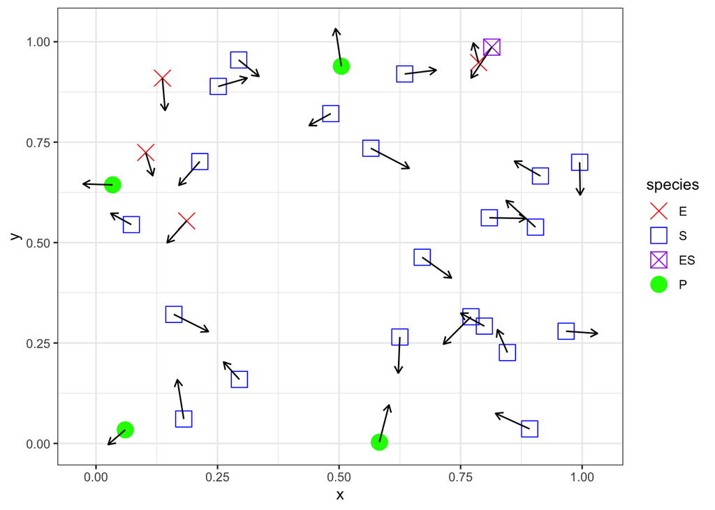

```r
set.seed(20230309)
n <- 30

d <- data.frame(
  x = runif(n),
  y = runif(n),
  species = sample(c("E","S","ES","P"), size = n, replace = TRUE,
                   prob = c(0.2,0.6,0.1,0.1)),
  speed = runif(n,0.05, 0.1),
  direction = runif(n, max = 2*pi)
) %>%
  mutate(
    xend = x + speed*cos(direction),
    yend = y + speed*sin(direction),
    species = factor(species, levels = c("E","S","ES","P"))
  )



ggplot(d, aes(x = x, y = y, xend = xend, yend=yend,
              color = species, shape = species)) +
  geom_point(size = 5) +
  geom_segment(arrow = arrow(length = unit(0.2, "cm")), color = "black") +
  scale_color_manual(
    values = c(
      "E" = "red",
      "S" = "blue",
      "ES" = "purple",
      "P" = "green"
    )
  ) +
  scale_shape_manual(
    values = c(
      "E" = 4,
      "S" = 0,
      "ES" = 7,
      "P" = 19
    )
  )
```

These reactions can be coded by indicting two matrices: Pre and Post. These matrices indicate the reactants (Pre) and the products (Post).

```r
Pre <- rbind(
#   E  S ES  P
  c(1, 1, 0, 0),
  c(0, 0, 1, 0),
  c(0, 0, 1, 0)
)

rownames(Pre) <- c("I","II","III")
colnames(Pre) <- c("E","S","ES","P")
Pre
```

```
##     E S ES P
## I   1 1  0 0
## II  0 0  1 0
## III 0 0  1 0
```

```r
Post <- rbind(
#   E  S ES  P
  c(0, 0, 1, 0),
  c(1, 1, 0, 0),
  c(1, 0, 0, 1)
)

rownames(Post) <- c("I","II","III")
colnames(Post) <- c("E","S","ES","P")
Post
```

```
##     E S ES P
## I   0 0  1 0
## II  1 1  0 0
## III 1 0  0 1
```

The *reaction* matrix is constructed by subtracting these and the *stoichiometry* matrix by transposing the reaction matrix.

```r
A <- Post - Pre # reaction
S <- t(A)       # stoichiometry

A
```

```
##      E  S ES P
## I   -1 -1  1 0
## II   1  1 -1 0
## III  1  0 -1 1
```

```r
S
```

```
##     I II III
## E  -1  1   1
## S  -1  1   0
## ES  1 -1  -1
## P   0  0   1
```

We can update the state of the system by either the stoichiometry or reaction matrix.

```r
x0 <- c(5, 100, 1, 0)
x0 + S[,1]
```

```
##  E  S ES  P
##  4 99  2  0
```

```r
x0 + S[,2]
```

```
##   E   S  ES   P
##   6 101   0   0
```

```r
x0 + S[,3]
```

```
##   E   S  ES   P
##   6 100   0   1
```

To determine which reaction occurs we need to calculate the *propensity* of the reaction. The propensity is the product of two components: the reaction rate and the number of combinations of the Pre molecules.

For this model we have the following propensities:
$$\begin{array}{rll}
I:& \lambda_1 E \cdot S \\
II:& \lambda_2 ES \\
III:& \lambda_3 ES \\
\end{array}$$

## Simulation

To simulate this continuous time Markov process, we iterate through these steps

1. Simulate a time increment which has an exponential distribution with rate equal to the sum of the propensities.
2. Simulate which reaction occurred which has a discrete distribution with probability proportional to the propensity.
3. Update time according to the time increment.
4. Update the state according to the reaction/stoichiometry matrix

#### R implementation

```r
michaelis_menton_reaction_matrix <- rbind(
  #  E   S  ES P
  c(-1, -1,  1, 0),
  c( 1,  1, -1, 0),
  c( 1,  0, -1, 1)
)

#' Function to simulate a single Michaelis-Menton transition
#'
#' This function will simulate a single predator-prety transition based on the
#' current `state` of the system and the reaction `rates`
simulate_michaelis_menton_transition <- function(state, rate, initial_time) {
  propensity <- c(
    rate[1] * state[1] * state[2],
    rate[2] * state[3] ,
    rate[3] * state[3]
  )

  time_increment <- rexp(1, rate = sum(propensity))
  reaction       <- sample(1:3, 1, prob = propensity)

  state <- state + michaelis_menton_reaction_matrix[reaction,]

  return(
    list(
      time  = initial_time + time_increment,
      state = state
    ))
}
```

```r
simulate_michaelis_menton_system <- function(initial_state, rate, max_rxns = 1e3) {
  # Create storage structures for state and time
  n_possible_rxns <- max_rxns + 1
  state <- matrix(initial_state, nrow = 4, ncol = n_possible_rxns)
  n_rxns <- 1
  time   <- rep(0, n_possible_rxns)

  # Simulate outbreak
  while(any(state[2:3,n_rxns] > 0) & n_rxns <= max_rxns) {
    tmp <- simulate_michaelis_menton_transition(state[,n_rxns], rate, time[n_rxns])
    n_rxns         <- n_rxns + 1
    time[n_rxns]   <- tmp$time
    state[,n_rxns] <- tmp$state
  }

  d <- data.frame(
    E  = state[1, ],
    S  = state[2, ],
    ES = state[3, ],
    P  = state[4, ],
    time = time
  ) %>%
    pivot_longer(-time, names_to = "state", values_to = "count") %>%
    mutate(
      state = factor(state, levels = c("E","S","ES","P"))
    )
}
```

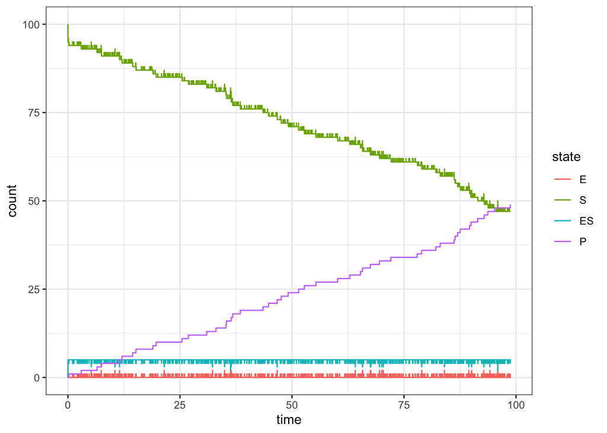

```r
set.seed(1)
d <- simulate_michaelis_menton_system(c(5, 100, 0, 0), rate = c(1,1,.1), max_rxns = 1e3)

ggplot(d, aes(x = time, y = count, color = state)) +
  geom_step()
```

This model is a continuous time Markov process because

1. Time can be incremented by any amount (rather than a discrete amount).
2. The state of the system is updated based on the current state (as opposed to past history).

## Examples

### SIR Model

The SIR model has three states:

- [S]usceptible
- [I]nfectious
- [R]ecovered

There are two reactions that can occur
$$\begin{array}{r\quad{}ll}
I:&S + I &\stackrel{\lambda}{\to} 2I \\
II:&I &\stackrel{\rho}{\to} R
\end{array}$$

The propensity of these reactions are
$$\begin{array}{r\quad{}ll}
I:& \lambda \, S\cdot I / N \\
II:& \rho \, I
\end{array}$$

The system is updated by the reaction matrix

$$\begin{array}{r|rrr}
& S & I & R \\
\hline
I & -1 & 1 & 0 \\
II & 0 & -1 & 1\\
\end{array}$$

Due to the two reactions converting a single individual from one state to another, this model has a constant population size.

#### R implementation

```r
sir_reaction_matrix <- rbind(
  #  S   I  R
  c(-1,  1, 0),
  c( 0, -1, 1)
)

#' Function to simulate a single SIR transition
#'
#' This function will simulate a single SIR transition based on the current
#' `state` of the system and the reaction `rates`
simulate_sir_transition <- function(state, rate, initial_time) {
  propensity <- c(
    rate[1] * state[1] * state[2] / sum(state),
    rate[2] * state[2]
  )

  time_increment <- rexp(1, rate = sum(propensity))
  reaction       <- sample(1:2, 1, prob = propensity)

  # Update state according to stoichiometry
  state <- state + sir_reaction_matrix[reaction,]

  return(
    list(
      time  = initial_time + time_increment,
      state = state
    ))
}
```

```r
simulate_outbreak <- function(initial_state, rate, max_rxns = 5000) {
  # Create storage structures for state and time
  n_possible_rxns <- min(2*initial_state[1] + initial_state[2]+1, max_rxns + 1)
  state <- matrix(initial_state, nrow = 3, ncol = n_possible_rxns)
  n_rxns <- 1
  time   <- rep(0, n_possible_rxns)

  # Simulate outbreak
  while(state[2,n_rxns] > 0 & n_rxns <= max_rxns ) {
    tmp <- simulate_sir_transition(state[,n_rxns], rate, time[n_rxns])
    n_rxns         <- n_rxns + 1
    time[n_rxns]   <- tmp$time
    state[,n_rxns] <- tmp$state
  }

  # Clean up data frames
  n <- which(state[2,] == 0)

  d <- data.frame(
    S = state[1, 1:n],
    I = state[2, 1:n],
    R = state[3, 1:n],
    time = time[1:n]
  ) %>%
    pivot_longer(-time, names_to = "state", values_to = "count") %>%
    mutate(
      state = factor(state, levels = c("S","I","R"))
    )
}
```

Sometimes the outbreak will die out right away

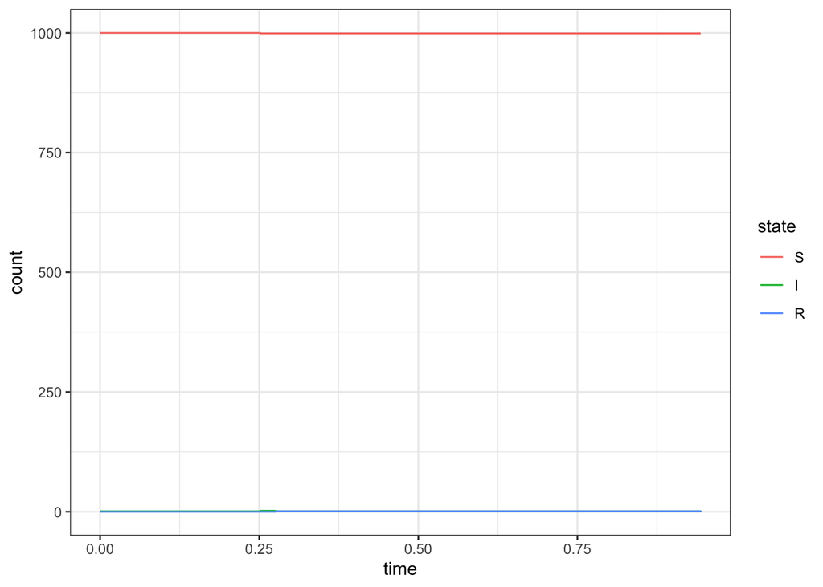

```r
set.seed(1)
d <- simulate_outbreak(c(1000, 1, 0), rate = c(2,1))

ggplot(d, aes(x = time, y = count, color = state)) +
  geom_step()
```

Sometimes the outbreak will last a while

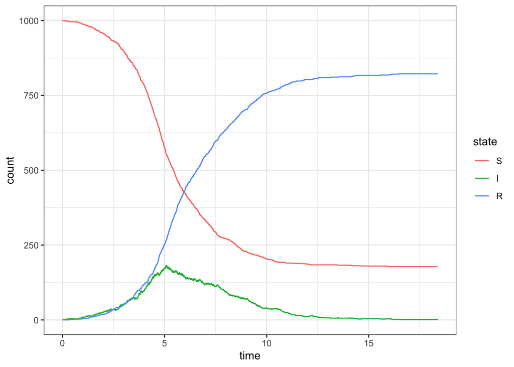

```r
set.seed(4)
d <- simulate_outbreak(c(1000, 1, 0), rate = c(2,1))

ggplot(d, aes(x = time, y = count, color = state)) +
  geom_step()
```

#### Scientific questions

One question we might ask is: what is the probability the outbreak will die out quickly (before time 5) for a given initial state and reaction rates.

To answer this question, we can run a Monte Carlo study

```r
X0 <- c(1000, 2, 0)
rate <- c(2,1)

die_out <- replicate(1e3, {
  d <- simulate_outbreak(X0, rate)
  return(max(d$time) < 5)
})

mean(die_out)
```

```
## [1] 0.258
```

```r
binom.test(sum(die_out), length(die_out))$conf.int
```

```
## [1] 0.2311271 0.2863056
## attr(,"conf.level")
## [1] 0.95
```

Another question could be, given the outbreak lasts longer than 5, what is the expected number of people who will be infected?

```r
X0 <- c(1000, 1, 0)
rate <- c(2,1)

infected <- replicate(1e3, {
  d <- simulate_outbreak(X0, rate)
  while(max(d$time) < 5)
    d <- simulate_outbreak(X0, rate)
  return(max(d$count[d$state == "R"]))
})

t.test(infected)$conf.int
```

```
## [1] 791.6672 797.3448
## attr(,"conf.level")
## [1] 0.95
```

### Lotka-Volterra Model

A simple predator-prey model (stochastic version of the Lotka-Volterra Model) has two states:

- [R]abbits
- [F]oxes

The propensity of these reactions are
$$\begin{array}{r\quad{}ll}
I:& \lambda \, R \\
II:& \rho \, F\cdot R\\
II:& \delta \, F
\end{array}$$

The system is updated by the reaction matrix

$$\begin{array}{r|rrr}
& R & F \\
\hline
I & 1 & 0 \\
II & -1 & 1 \\
III & 0 & -1
\end{array}$$

This model does not have a constant population size.

#### R implementation

```r
predator_prey_reaction_matrix <- rbind(
  #  R   F
  c( 1,  0),
  c(-1,  1),
  c( 0, -1)
)

#' Function to simulate a single predator-prey transition
#'
#' This function will simulate a single predator-prety transition based on the
#' current `state` of the system and the reaction `rates`
simulate_transition <- function(state, rate, initial_time) {
  propensity <- c(
    rate[1] * state[1],
    rate[2] * state[1] * state[2],
    rate[3] * state[2]
  )

  time_increment <- rexp(1, rate = sum(propensity))
  reaction       <- sample(1:3, 1, prob = propensity)

  # Update state according to reaction matrix
  state <- state + predator_prey_reaction_matrix[reaction,]

  return(
    list(
      time  = initial_time + time_increment,
      state = state
    ))
}
```

```r
simulate_predator_prey_system <- function(initial_state, rate, max_rxns = 1e4) {
  # Create storage structures for state and time
  n_possible_rxns <- max_rxns + 1
  state <- matrix(initial_state, nrow = 2, ncol = n_possible_rxns)
  n_rxns <- 1
  time   <- rep(0, n_possible_rxns)

  # Simulate outbreak
  while(state[2,n_rxns] > 0 & n_rxns <= max_rxns ) {
    tmp <- simulate_transition(state[,n_rxns], rate, time[n_rxns])
    n_rxns         <- n_rxns + 1
    time[n_rxns]   <- tmp$time
    state[,n_rxns] <- tmp$state
  }

  d <- data.frame(
    R = state[1, ],
    F = state[2, ],
    time = time
  ) %>%
    pivot_longer(-time, names_to = "state", values_to = "count") %>%
    mutate(
      state = factor(state, levels = c("R","F"))
    )
}
```

Sometimes the foxes will eat all the rabbits

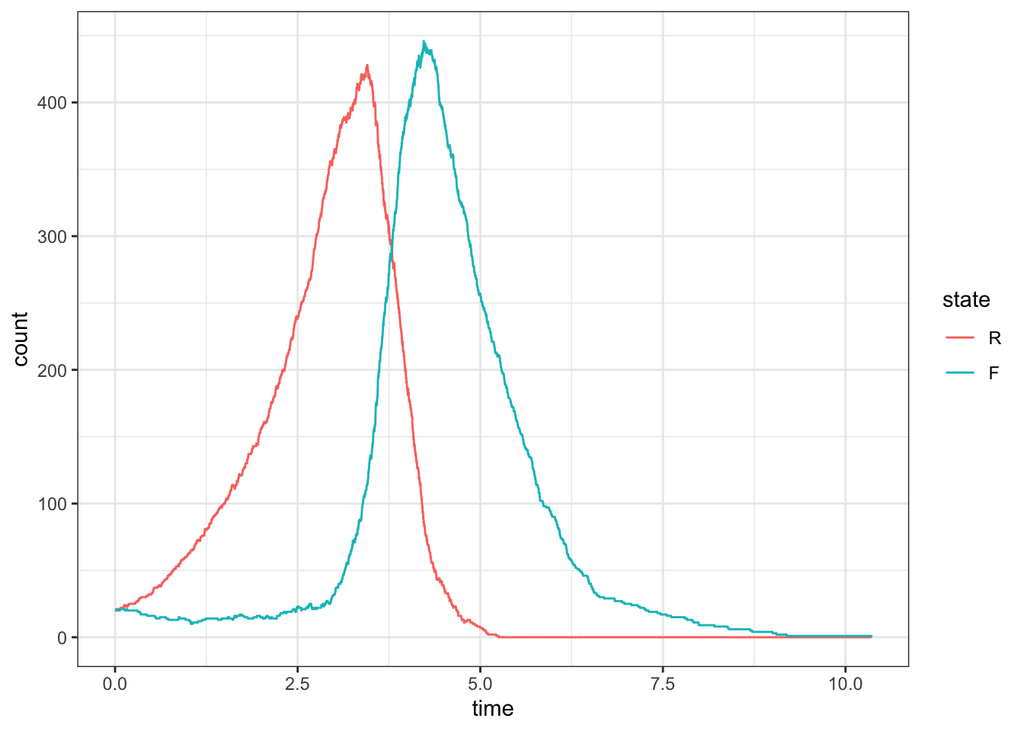

```r
set.seed(1)
d <- simulate_predator_prey_system(c(20,20), rate = c(1,.01,1), max_rxns = 1e5)

ggplot(d, aes(x = time, y = count, color = state)) +
  geom_step()
```